# Paso 2: Análisis exploratorio (EDA)

**Objetivo:** entender los patrones que el modelo debe capturar, antes de modelar nada. Un presupuesto es tan bueno como los supuestos que lo alimentan, y el EDA es donde esos supuestos se validan con datos en lugar de asumirse.

**Preguntas que responde este notebook:**

1. ¿Cuánto crece 2026 vs 2025? (define el *nivel* del presupuesto)
2. ¿Qué forma tiene la estacionalidad jul-dic? (define la *curva mensual*)
3. ¿Cómo se reparte la venta entre los días de la semana, y es estable? (define la *curva semanal*)
4. ¿Cómo se comportan los feriados? (define los *días especiales*)
5. ¿Cuántos productos concentran el volumen? (curva ABC — define dónde poner el esfuerzo)

```python
import pandas as pd
import matplotlib.pyplot as plt

daily = pd.read_parquet('daily.parquet')
maestro = pd.read_parquet('maestro.parquet')
plt.rcParams['figure.figsize'] = (10, 4)
```

## 1. Crecimiento interanual

Comparamos cada mes de 2026 contra el mismo mes de 2025. Si el negocio creció, el nivel del presupuesto debe anclarse en 2026 (los meses recientes) y **no** en el nivel de 2025.

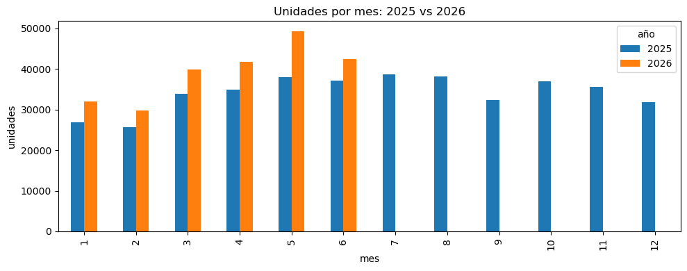

```
mes
1    +18.7%
2    +15.6%
3    +18.0%
4    +19.9%
5    +29.8%
6    +14.2%
Name: crecimiento, dtype: object

Crecimiento promedio ene-jun: +19.4%
```

```python
m = daily.groupby(['año', daily['FECHA'].dt.month])['CANTIDAD'].sum().unstack('año')
m.index.name = 'mes'
m['crecimiento'] = (m[2026] / m[2025] - 1)

fig, ax = plt.subplots()
m[[2025, 2026]].plot(kind='bar', ax=ax, title='Unidades por mes: 2025 vs 2026')
ax.set_ylabel('unidades')
plt.tight_layout(); plt.show()

print(m['crecimiento'].dropna().map('{:+.1%}'.format))
print(f"\nCrecimiento promedio ene-jun: {m['crecimiento'].dropna().mean():+.1%}")
```

**Lectura:** 2026 vende consistentemente entre +14% y +30% sobre 2025 (promedio ≈ +19%). Conclusión metodológica: 2025 sirve para la **forma** (estacionalidad, curva semanal) pero no para el **nivel**. El nivel sale de mayo-junio 2026, como definimos en las premisas.

## 2. Estacionalidad mensual

Calculamos el factor de cada mes de 2025 relativo al promedio mayo-junio 2025 (la misma ventana que usamos como base en 2026). Ese factor, aplicado a la base 2026, proyecta jul-dic 2026. Es la formalización exacta de tu premisa: *"analizar la estacionalidad de los mismos meses del año anterior y aplicarla a 2026"*.

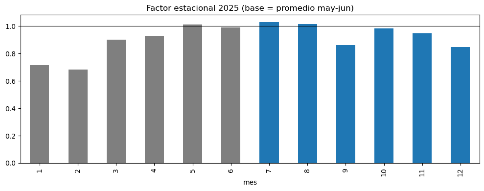

```
mes
7     1.030
8     1.016
9     0.861
10    0.984
11    0.946
12    0.848
Name: 2025, dtype: float64
```

```python
u25 = m[2025]
base_ventana = u25.loc[[5, 6]].mean()          # promedio may-jun 2025
factor_estacional = u25 / base_ventana

fig, ax = plt.subplots()
factor_estacional.plot(kind='bar', ax=ax, color=['tab:gray']*6 + ['tab:blue']*6,
                       title='Factor estacional 2025 (base = promedio may-jun)')
ax.axhline(1, color='k', lw=0.8)
plt.tight_layout(); plt.show()

print(factor_estacional.loc[7:].round(3))
```

## 3. Curva por día de semana

Tu diagnóstico del presupuesto anterior era correcto: repartir el mes en partes iguales por día ignora que no todos los días pesan igual. Acá medimos ese peso con 2026 (comportamiento actual) y lo validamos contra 2025 (¿es estable en el tiempo?). Excluimos lunes y feriados.

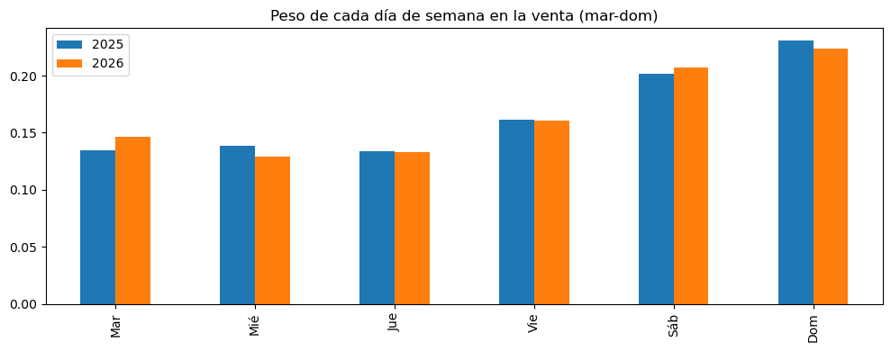

```
      2025   2026
Mar  0.134  0.147
Mié  0.138  0.129
Jue  0.134  0.133
Vie  0.161  0.161
Sáb  0.202  0.207
Dom  0.231  0.224

Por tienda (2026):
Tienda  Sinclair  Ugarteche
Mar        0.155      0.135
Mié        0.129      0.130
Jue        0.130      0.137
Vie        0.154      0.170
Sáb        0.201      0.215
Dom        0.231      0.212
```

```python
feriados_hist = pd.to_datetime(['2025-06-23', '2025-07-14', '2025-11-17',
                                 '2025-11-24', '2025-12-08', '2026-06-22'])
d = daily[~daily['FECHA'].isin(feriados_hist) & (daily['dow'] > 0)]

def pesos_dow(df):
    por_fecha = df.groupby(['FECHA', 'dow'])['CANTIDAD'].sum().reset_index()
    prom = por_fecha.groupby('dow')['CANTIDAD'].mean()
    return prom / prom.sum()

w = pd.DataFrame({
    '2025': pesos_dow(d[d['año'] == 2025]),
    '2026': pesos_dow(d[d['año'] == 2026]),
})
w.index = ['Mar', 'Mié', 'Jue', 'Vie', 'Sáb', 'Dom']

w.plot(kind='bar', title='Peso de cada día de semana en la venta (mar-dom)')
plt.tight_layout(); plt.show()
print(w.round(3))

# ¿Las dos tiendas tienen la misma curva?
d26 = d[d['año'] == 2026]
por_tienda = (d26.groupby(['Tienda', 'FECHA', 'dow'])['CANTIDAD'].sum()
                 .reset_index().groupby(['Tienda', 'dow'])['CANTIDAD'].mean())
wt = (por_tienda / por_tienda.groupby('Tienda').transform('sum')).unstack('Tienda')
wt.index = ['Mar', 'Mié', 'Jue', 'Vie', 'Sáb', 'Dom']
print('\nPor tienda (2026):')
print(wt.round(3))
```

## 4. Feriados — el hallazgo más importante del EDA

Las reglas de negocio dicen: en jul-dic 2026 se abre el 9/7 (jueves), los lunes feriados 17/8, 12/10 y 23/11, el lunes puente 7/12, y se cierra el 25/12. Pero ¿cuánto vende un feriado? Los datos dicen que depende del tipo de feriado:

```python
def ratio_vs_dia_normal(fecha, df):
    fecha = pd.Timestamp(fecha)
    mes_df = df[(df['FECHA'].dt.year == fecha.year) & (df['FECHA'].dt.month == fecha.month)]
    venta_feriado = mes_df[mes_df['FECHA'] == fecha]['CANTIDAD'].sum()
    # comparamos contra el promedio del mejor proxy: mismo dow (o martes si es lunes)
    dow_ref = fecha.dayofweek if fecha.dayofweek != 0 else 1
    normal = (mes_df[(mes_df['dow'] == dow_ref) & (mes_df['FECHA'] != fecha)]
              .groupby('FECHA')['CANTIDAD'].sum().mean())
    return venta_feriado, normal, venta_feriado / normal

casos = {'2025-07-09 (mié, Independencia)': '2025-07-09',
         '2026-05-01 (vie, Trabajador)':    '2026-05-01',
         '2026-06-22 (lun feriado, 1ª apertura)': '2026-06-22'}
for nombre, f in casos.items():
    v, n, r = ratio_vs_dia_normal(f, daily)
    print(f"{nombre}: {v:,.0f} unidades vs {n:,.0f} de un día comparable -> ratio {r:.2f}")

# Días especiales de diciembre 2025
byday = daily[daily['mes'] == '2025-12'].groupby('FECHA')['CANTIDAD'].sum()
print(f"\n24/12/2025 (Nochebuena): {byday['2025-12-24']:,} vs miércoles normal ~1.158 -> ratio 1.46")
print(f"26/12/2025: {byday['2025-12-26']:,} (post-Navidad, muy flojo)")
print(f"31/12/2025: {byday['2025-12-31']:,} -> ratio ~1.19")
```

```
2025-07-09 (mié, Independencia): 2,200 unidades vs 1,099 de un día comparable -> ratio 2.00
2026-05-01 (vie, Trabajador): 2,465 unidades vs 1,594 de un día comparable -> ratio 1.55
2026-06-22 (lun feriado, 1ª apertura): 487 unidades vs 1,274 de un día comparable -> ratio 0.38

24/12/2025 (Nochebuena): 1,686 vs miércoles normal ~1.158 -> ratio 1.46
26/12/2025: 722 (post-Navidad, muy flojo)
31/12/2025: 1,374 -> ratio ~1.19
```

**Lectura — tres comportamientos distintos:**

1. **Feriados que caen en día de apertura normal venden MÁS, no menos:** el 9 de Julio 2025 vendió el doble de un miércoles normal (2.00x) y el 1 de Mayo 2026 un 55% más que un viernes normal (1.55x). Tiene lógica gastronómica: la gente está en la calle.
2. **Los lunes feriados abiertos son territorio nuevo:** en 2025 las tiendas NO abrían los lunes feriados (14/7, 24/11 y 8/12 de 2025 tienen venta ~cero). La primera apertura real fue el 22/6/2026 y vendió solo el 38% de un martes normal. Un solo dato, pero es el único que hay.
3. **Diciembre tiene su propia microestacionalidad:** Nochebuena +46%, el 26 se desploma, el 31 +19%.

**Parámetros propuestos para el modelo** (a validar con negocio): | Día especial | Tratamiento | |---|---| | Jue 9/7 | jueves normal × **1.75** (promedio de los ratios observados 2.00 y 1.55) | | Lun 17/8, 12/10, 23/11, 7/12 | martes del mes × **0.38** (único precedente: 22/6/2026) | | Jue 24/12 | jueves normal × **1.45** | | Vie 25/12 | **0** (cerrado) | | Sáb 26/12 | sábado normal × **0.60** | | Jue 31/12 | jueves normal × **1.20** |

## 5. Curva ABC de productos

¿Dónde está el volumen? Esto define expectativas: los productos A tendrán pronósticos precisos, la cola larga C es intrínsecamente ruidosa (demanda intermitente) y su error individual alto, aunque en agregado compense.

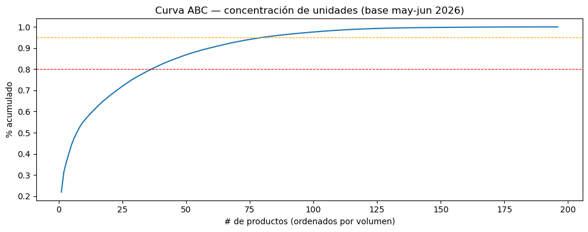

```
Productos activos en may-jun 2026: 196
Explican el 80% de las unidades: 36 productos
Explican el 95%: 79 productos

Top 10:
ARTÍCULO
Medialuna Dulce                       20153
Chipa                                  8770
Sacramento con Crema Pastelera         4341
Papel Boûlan                           3770
Sacramento con Dulce de Leche          3650
Vigilante Gigante                      2797
Baguette                               2310
Pan Frances                            2133
Bizcocho de Grasa                      1868
Pan de Molde Integral con Semillas     1329
Name: CANTIDAD, dtype: int64
```

```python
base = daily[(daily['año'] == 2026) & (daily['FECHA'].dt.month.isin([5, 6]))]
abc = base.groupby('CÓDIGO')['CANTIDAD'].sum().sort_values(ascending=False)
acum = abc.cumsum() / abc.sum()

fig, ax = plt.subplots()
ax.plot(range(1, len(acum) + 1), acum.values)
ax.axhline(0.8, color='r', ls='--', lw=0.8); ax.axhline(0.95, color='orange', ls='--', lw=0.8)
ax.set_title('Curva ABC — concentración de unidades (base may-jun 2026)')
ax.set_xlabel('# de productos (ordenados por volumen)'); ax.set_ylabel('% acumulado')
plt.tight_layout(); plt.show()

print(f"Productos activos en may-jun 2026: {len(abc)}")
print(f"Explican el 80% de las unidades: {(acum <= 0.8).sum()} productos")
print(f"Explican el 95%: {(acum <= 0.95).sum()} productos")
print("\nTop 10:")
print(base.groupby('ARTÍCULO')['CANTIDAD'].sum().sort_values(ascending=False).head(10))
```

**Lectura:** 36 productos (18% del surtido) explican el 80% de las unidades; 79 explican el 95%. La Medialuna Dulce sola es ~22% del volumen. El presupuesto incluirá los **196 productos activos** en may-jun 2026, pero al evaluar modelos miraremos el error ponderado por volumen (WMAPE), que es lo que le importa al negocio.

**Próximo paso (notebook 03):** construir el **Modelo A (baseline)** con estos parámetros — base may-jun 2026 × factor estacional mensual por familia × curva semanal por tienda × ajustes de días especiales — y el esquema de backtesting para medirlo.